# Statistics: The Science of Decisions

```python
from pandas import *
dataFrame = read_csv('stroopdata.csv')
```

```python
dataFrame
```

|  | Congruent | Incongruent |
| --- | --- | --- |
| 0 | 12.079 | 19.278 |
| 1 | 16.791 | 18.741 |
| 2 | 9.564 | 21.214 |
| 3 | 8.630 | 15.687 |
| 4 | 14.669 | 22.803 |
| 5 | 12.238 | 20.878 |
| 6 | 14.692 | 24.572 |
| 7 | 8.987 | 17.394 |
| 8 | 9.401 | 20.762 |
| 9 | 14.480 | 26.282 |
| 10 | 22.328 | 24.524 |
| 11 | 15.298 | 18.644 |
| 12 | 15.073 | 17.510 |
| 13 | 16.929 | 20.330 |
| 14 | 18.200 | 35.255 |
| 15 | 12.130 | 22.158 |
| 16 | 18.495 | 25.139 |
| 17 | 10.639 | 20.429 |
| 18 | 11.344 | 17.425 |
| 19 | 12.369 | 34.288 |
| 20 | 12.944 | 23.894 |
| 21 | 14.233 | 17.960 |
| 22 | 19.710 | 22.058 |
| 23 | 16.004 | 21.157 |

### Variables

The independent variable in this experiment is the reading condition, specifically whether text of words are written in the colour that they describe (congruent), or in a colour other than the one that they describe.

The dependent variable in this experiment is the time taken to read the list of words.

### Null and alternative hypotheses

The null hypothesis is that population mean of congruent times is equal to the population mean of incongruent times.

- $H_0$: $\mu_C = \mu_I$ (where $\mu_C$ is the congruent population mean and $\mu_I$ is the incongruent population mean.)

The alternative hypothesis is that population mean of congruent times is *not* equal to the population mean of incongruent times.

- $H_1$: $\mu_C \neq \mu_I$

### Statistical test rationale

Using sample data from congruent and incongruent times, we will conduct a *two- tailed, two-sample dependent t-test* of the null hypothesis. We will making the following assumptions about the data

- Participants have recorded a congruent and subsequent incongruent time, i.e. the population is the same and times are paired across the two groups.
- Population of congruent and incongruent times are iid normal.
- Variances of groups *are* assumed to be equal.
- Data distributions that are roughly symmetric/mound (Gaussian) shaped and not skewed.

For this analysis, we will use a signficance value of $\alpha = 0.05$.

### Measures of central tendency and variance

```python
#Calculate the mean time to complete the congruent and incongruent exercise
print "The mean time taken for the congruent condition is =", dataFrame["Congruent"].mean()
print "The mean time taken for the incongruent condition is =", dataFrame["Incongruent"].mean()

#Calculate the  the congruent and incongruent variances
print "The congruent time variance =", dataFrame["Congruent"].var()
print "The incongruent time variance =", dataFrame["Incongruent"].var()
```

```
The mean time taken for the congruent condition is = 14.051125
The mean time taken for the incongruent condition is = 22.0159166667
The congruent time variance = 12.6690290707
The incongruent time variance = 23.0117570362
```

### Exploring the data with visualisations

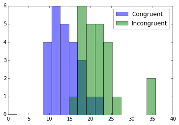

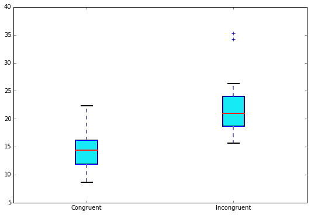

```python
#Histogram of congruent and incongruent
#source: http://stackoverflow.com/questions/6871201/plot-two-histograms-at-the-same-time-with-matplotlib

import matplotlib as mpl
mpl.use('agg')
import matplotlib.pyplot as plt
%matplotlib inline

import numpy
from pandas import *


dataFrame = read_csv('stroopdata.csv')

x = dataFrame["Congruent"]
y = dataFrame["Incongruent"]

bins = numpy.linspace(0, 40, 20)

plt.hist(x, bins, alpha=0.5, label='Congruent')
plt.hist(y, bins, alpha=0.5, label='Incongruent')
plt.legend(loc='upper right')
plt.show()

#Box plot of the congruent and incongruent times
#Source: http://blog.bharatbhole.com/creating-boxplots-with-matplotlib/

dataFrame = read_csv('stroopdata.csv')

plotData = [dataFrame["Congruent"], dataFrame["Incongruent"]]

# Create a figure instance
fig = plt.figure(1, figsize=(9, 6))

# Create an axes instance
ax = fig.add_subplot(111)

# Create the boxplot
bp = ax.boxplot(plotData)

# Save the figure
fig.savefig('fig1.png', bbox_inches='tight')

## add patch_artist=True option to ax.boxplot()
## to get fill color
bp = ax.boxplot(plotData, patch_artist=True)

## change outline color, fill color and linewidth of the boxes
for box in bp['boxes']:
    # change outline color
    box.set(facecolor = '#16EAF5', linewidth=2)

## change color and linewidth of the whiskers
for whisker in bp['whiskers']:
    whisker.set(color='#7570b3', linewidth=2)

## change color and linewidth of the caps
for cap in bp['caps']:
    cap.set(linewidth=2)

## change color and linewidth of the medians
for median in bp['medians']:
    median.set(color='#F62217', linewidth=2)

ax.set_xticklabels(['Congruent', 'Incongruent'])
```